# Lecture 17 - Data Types

2022-11-29

## Packages for this lecture

```r
library(tidyverse)
library(babynames)
library(nycflights13)
library(hms)
library(lubridate)
```

## Strings

`str_sub`

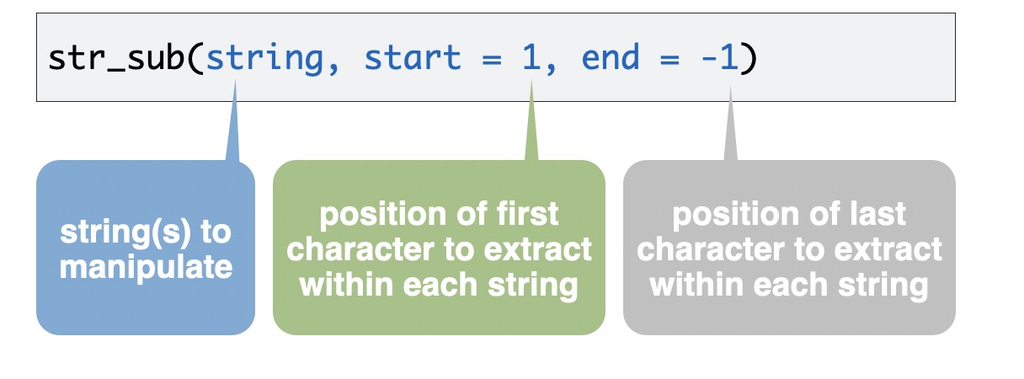

## `str_sub`

```r
str_sub("Garrett", 1, 2)
str_sub("Garrett", 3)
str_sub("Garrett", -2)

g <- "Garrett"
str_sub(g, -3) <- "eth"
g
```

You can type `help(package = stringr)` to open the file directory of stringr

## Your turn

We would like to know the trend of the proportions of babynames which end in a vowel. Use `babynames` data:

1. Isolate the last letter of every name
2. Create a logical variable vowel that displays whether the last letter is one of “a”, “e”, “i”, “o”, or “u”.
3. Use the weighted mean function weighted.mean(vowel, n) to calculate the proportion of children whose name ends in a vowel (by year and sex)
4. Display the results as a line plot.

## `str_detect`

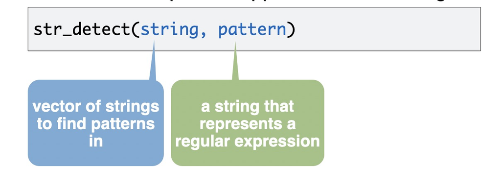

## `str_detect`

```r
strings <- c("Apple", "Orange")
str_detect(strings, "pp")
```

```
## [1]  TRUE FALSE
```

```r
strings <- c("Apple", "Pineapple")
str_detect(strings, "apple")
```

```
## [1] FALSE  TRUE
```

## Atomic types and classes

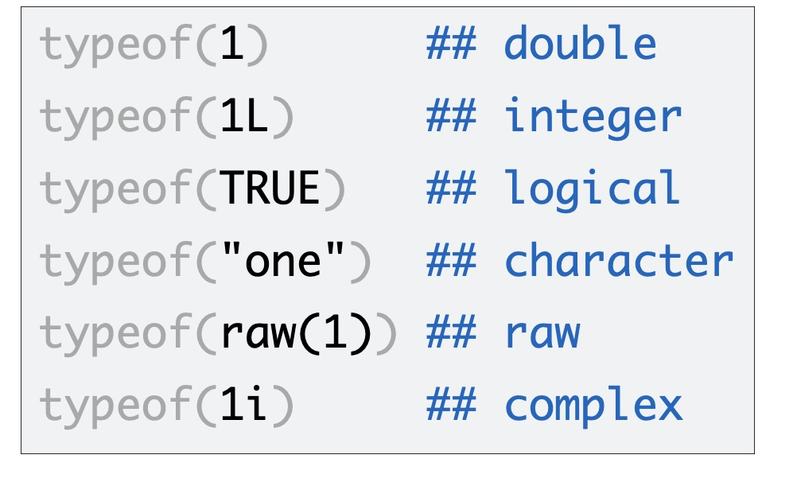

## Factors

R uses factors to represent categorical variables. Factor consists of:

1. A set of values
2. A set of valid levels

Factors are stored as an integer value with a levels attribute

```r
a <- c(1,1,3,2,3,1)
factor(a)
factor(a,labels=c("blue","brown","green"))

eyes <- factor(x = c("blue", "green", "green"),
          levels = c("blue", "brown", "green"))

gss_cat
```

## Which religions watch the least TV

```r
gss_cat %>%
  filter(!is.na(tvhours)) %>%
  group_by(relig) %>%
  summarize(tvhours = mean(tvhours)) %>%
  ggplot(aes(tvhours, relig)) +
    geom_point()
```

## Which religions watch the least TV

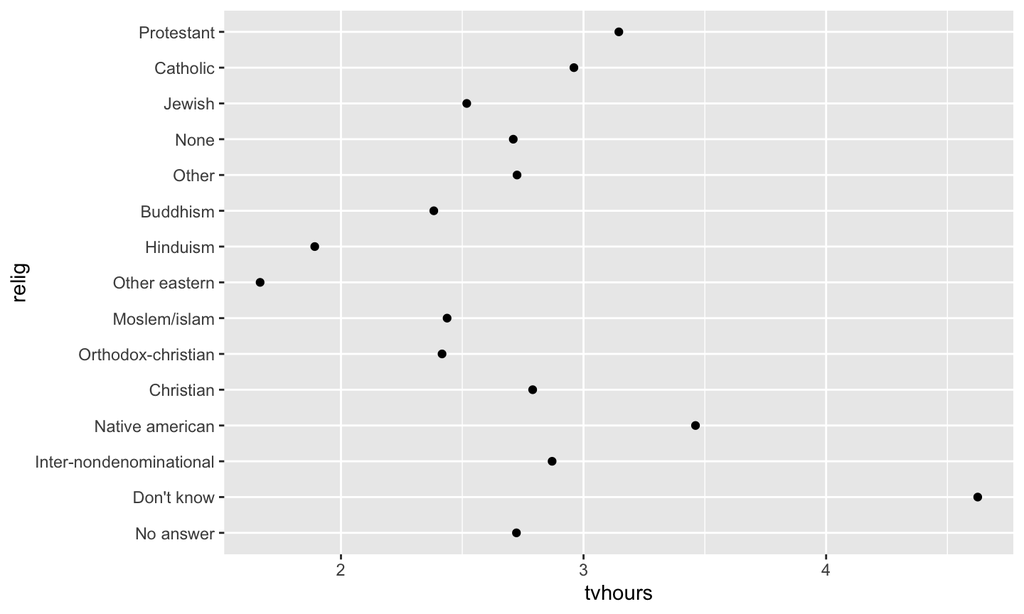

## `fct_reorder`

Reorders the levels of a factor based on the result of fun(x) applied to each group of cases (grouped by level)

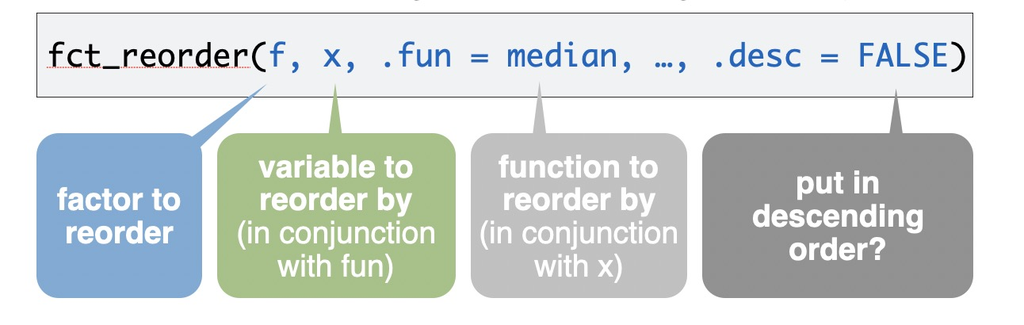

## `fct_reorder`

```r
gss_cat %>%
  filter(!is.na(tvhours)) %>%
  group_by(relig) %>%
  summarize(tvhours = mean(tvhours)) %>%
  ggplot(aes(tvhours, fct_reorder(relig, tvhours,.fun = mean))) +
    geom_point()
```

## `fct_reorder`

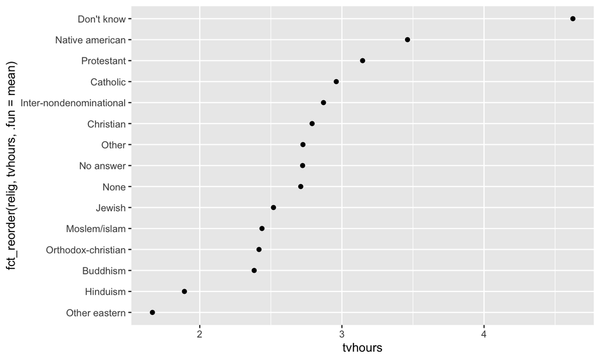

## Your turn

Make a sensible graph of average TV consumption by marital status.

## Other reordering functions

```r
gss_cat %>%
  ggplot(aes(marital)) + geom_bar()

gss_cat %>%
  ggplot(aes(fct_infreq(marital))) + geom_bar()

gss_cat %>%
  ggplot(aes(fct_rev(fct_infreq(marital)))) + geom_bar()
```

## fct_recode()

Compute the average tv hours by party ID and then plot the results

```r
gss_cat %>%
   filter(!is.na(tvhours)) %>%
   group_by(partyid) %>%
   summarise(tvhours = mean(tvhours)) %>%
   ggplot(aes(tvhours, fct_reorder(partyid, tvhours))) +
     geom_point() +
     labs(y = "partyid")
```

## fct_recode()

Compute the average tv hours by party ID and then plot the results

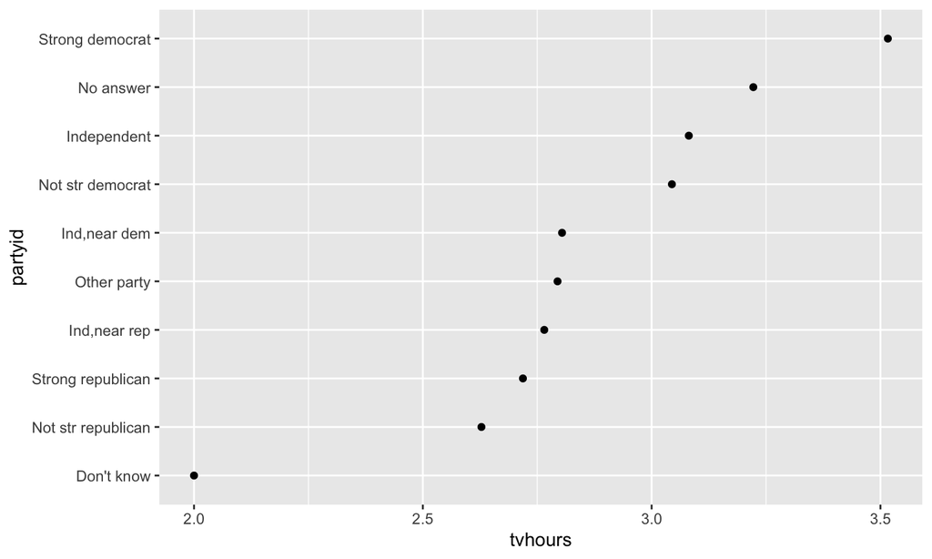

## fct_recode()

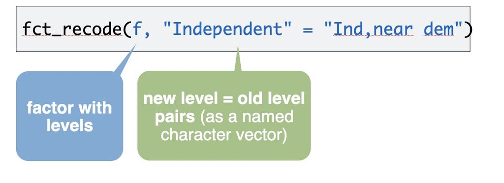

## `fct_recode()`

```r
gss_cat %>%
   filter(!is.na(tvhours)) %>%
    mutate(partyid = fct_recode(partyid,
    "Republican, strong"    = "Strong republican",
    "Republican, weak"      = "Not str republican",
    "Independent, near rep" = "Ind,near rep",
    "Independent, near dem" = "Ind,near dem",
    "Democrat, weak"        = "Not str democrat",
    "Democrat, strong"      = "Strong democrat")) %>%
   group_by(partyid) %>%
   summarize(tvhours = mean(tvhours)) %>%
   ggplot(aes(tvhours, fct_reorder(partyid, tvhours))) +
     geom_point() + labs(y = "partyid")
```

## `fct_collapse()`

```r
gss_cat %>%
   filter(!is.na(tvhours)) %>%
    mutate(partyid = fct_collapse(partyid,
      "conservative" = c("Strong republican",
                       "Not str republican",
                       "Ind,near rep"),
      "liberal" = c("Strong democrat",
                  "Not str democrat",
                  "Ind,near dem"))) %>%
   group_by(partyid) %>%
   summarize(tvhours = mean(tvhours)) %>%
   ggplot(aes(tvhours, fct_reorder(partyid, tvhours))) +
     geom_point() + labs(y = "partyid")
```

## Date times

What is the best time of day to fly?

```r
flights %>%
  group_by(sched_dep_time) %>%
  summarize(arr_delay_avg = mean(arr_delay,na.rm=TRUE)) %>%
  ggplot(mapping = aes(x = sched_dep_time, y = arr_delay_avg)) +
    geom_point(alpha = 0.2) + geom_smooth()
```

## Date times

What is the best time of day to fly?

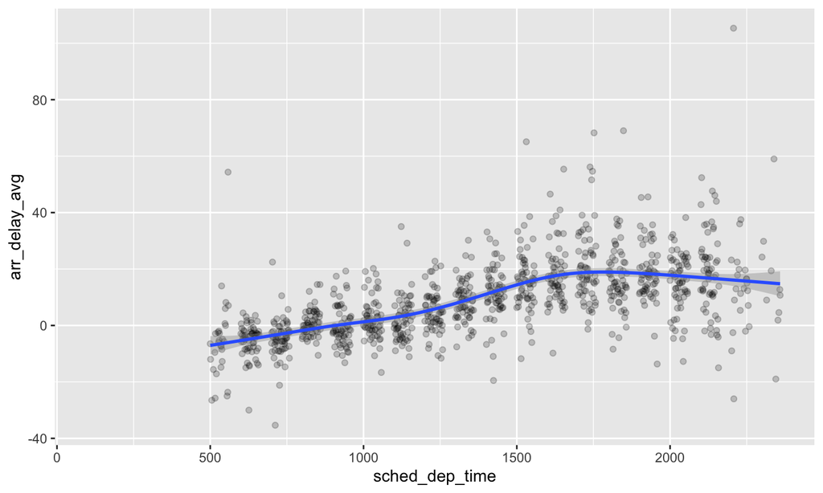

## Classes for time

R’s classes for time:

1. POSIXct. Stored as the number of seconds since 1970-01-01
2. Dates. Stored as the number of days since 1970-01-01

## Date time

```r
Sys.time()
```

```
## [1] "2022-11-29 14:21:12 EST"
```

```r
unclass(Sys.time())
```

```
## [1] 1669749673
```

```r
Sys.Date()
```

```
## [1] "2022-11-29"
```

```r
unclass(Sys.Date())
```

```
## [1] 19325
```

## `hms()`

Load the package `library(hms)`

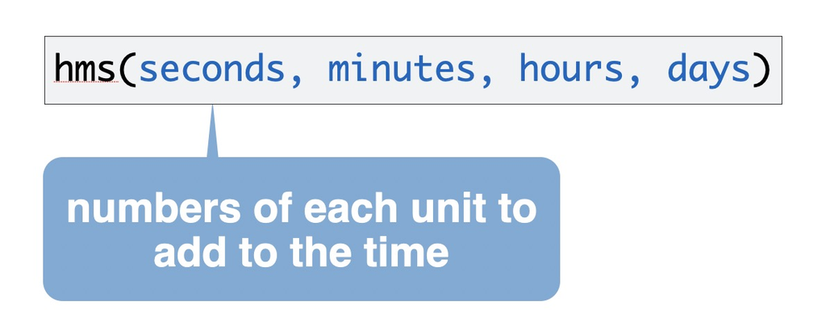

hms::hms(seconds = 56, min = 34, hour = 12)

## What is the best day of the week to fly?

Load the package `library(lubridate)`

To parse strings as dates, use the function whose name is y, m, d, h, m, s in the correct order.

```r
ymd("2012/01/11")
mdy("January 11 2012")
ymd_hms("2012-01-11  01:30:55")
```

Extract components by name with a singular name

```r
date <- ymd("2019-01-11")
year(date)
```

```
## [1] 2019
```

```r
year(date) <- 1999
date
```

```
## [1] "1999-01-11"
```

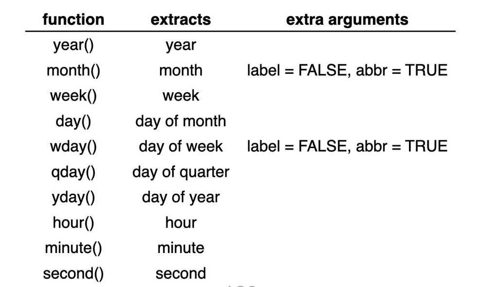

## Lubridate

```r
wday(ymd("2019-01-11"))
```

```
## [1] 6
```

```r
wday(ymd("2019-01-11"), label = TRUE)
```

```
## [1] Fri
## Levels: Sun < Mon < Tue < Wed < Thu < Fri < Sat
```

```r
wday(ymd("2019-01-11"), label = TRUE, abbr = FALSE)
```

```
## [1] Friday
## 7 Levels: Sunday < Monday < Tuesday < Wednesday < Thursday < ... < Saturday
```

## Your turn

- Extract the day of the week of each flight (as a full name) from time_hour. Plot the average arrival delay by day as a column chart (bar chart).